# Sally the Congressperson: A Psycho- and Sociolinguistic Investigation into the Relationship Between Ideology, Gender, and Language: Auxiliary Analysis

B. Papineau

Autumn 2021

# 1 Introduction

The code and information contained herein constitutes the complete write-up of the experiments I carried out for my first Qualifying Paper towards the PhD in Linguistics at Stanford University. The goal is to make this document both a dumping ground for my ideas while it is in progress, as well as, eventually, a publicly-available version of my Qualifying Paper, in the spirit of Open Science.

## 1.1 Preliminaries

### 1.1.1 Setting up the Notebook

For this write-up and analysis, I require the following packages, loaded in here:

```r
library(ggplot2)
library(tidyverse)
library(lme4)
library(stringr)
library(languageR)
library(lmerTest)
library(reshape2)
library(grid)

source("helpers.R")
```

I also use a custom color palette, so I include the code for that here as well[^1].

```r
bran_palette = c("#7ae7e5", "#fe5f55", "#B2A6DE", "#14342b", "#69385c")

theme_set(theme_minimal())
```

## 1.2 Self-Paced Reading Study

### 1.2.1 Methods

**Participants**

1. Were born in the United States
2. Lived in the United States at the time of participation
3. Spoke English as a first language
4. Had not participated in the norming study for the stimuli

These requirements were implemented in order to assure that speakers came from at least somewhat similar linguistic backgrounds, as certain lexical items in the study (such as *congressperson*) are quite localized to the United States.

After this initial run of the experiment, we found that there was a dearth of conservative or Republican-aligned participants. As a result, we ran the experiment again, this time on 98 self-identified Republicans. This was achieved by adding a filter on Prolific so that only Republican-identified individuals could see the task. The rest of the experiment, including payment, was exactly the same, except that an additional disclaimer that participants could not use the FireFox browser experiment, after the first run revealed an incompatibility between JavaScript and FireFox. The two runs of the experiment amounted in a total of 298 participants who completed the task.

### 1.2.2 Analysis

**Reading in the Data**

```r
sprt_data_comp_comp <- read.csv('sprt_data_comp.csv') %>%
  filter(trial_id != "example") %>%
  filter(word_idx < 3)
```

**Exclusions**

Now, we want to exclude any participants who failed to answer at least 85% of the attention check questions correctly. We do this by creating a list of all participants who scored less than 85% on these checks, and then cross-referencing this list with all data points, removing any data points whose participants were in the exclusion list.

```r
sprt_exclusion <- sprt_data_comp %>% group_by(workerid) %>%
  summarise(accuracy = mean(response_correct)) %>%
  mutate(exclude = ifelse(accuracy < 0.85,'Yes','No')) %>%
  filter(exclude == 'Yes')

sprt_data_comp <- sprt_data_comp[!(sprt_data_comp$workerid %in% sprt_exclusion$workerid),]
```

```r
sprt_data_comp <- sprt_data_comp %>%
  group_by(trial_id) %>%
  mutate(id_mean = mean(log(rt))) %>%
  mutate(exclusion = (log(rt) < mean(log(rt)) - 2*sd(log(rt))|(log(rt) > mean(log(rt)) + 2*sd(log(rt))))) %>%
  ungroup() %>%
  filter(exclusion==FALSE)
```

**Additional Information** Now that we have only the rows we want, let’s add some new columns, which will contain important information for each data point. Here, we will be adding:

- Gender Ideology Subscores
- Trial Genders
- Trial Morphology Types
- Critical Item Length & Length-Controlled Residuals
- Trial Congruency
- Partipant Political Affiliation

Ideally, I would’ve added all of these but the first when I actually created the stimuli and logged responses, but I forgot to! Luckily, R allows us to do this post-hoc fairly straightforwardly… which is good, since these features will be critical in our data visualization and analysis.

The question under investigation here is whether or not individuals’ conceptions of gender affect how they process gendered and gender-neutral forms of English personal and professional titles.  
In order to examine this, we need to quanify participants’ ideological views! Here we have adopted the 13-item Social Roles Questionnaire put forth in Baber & Tucker (2006). Questions 1-5 correlate to the *‘Gender Transcendent’* subscale, and questions 6-13 correspond to the *‘Gender Linked’* subscale. Each item is scored on a scale of 0-100. So, the first thing we want to do is make two lists of columns which correspond to these two subscales, since the questions are stored individually in the data:

```r
gender_transcendence_cols <- c('subject_information.gender_q1','subject_information.gender_q2','subject_information.gender_q3','subject_information.gender_q4','subject_information.gender_q5')

gender_linked_cols <- c('subject_information.gender_q6','subject_information.gender_q7','subject_information.gender_q8','subject_information.gender_q9','subject_information.gender_q10','subject_information.gender_q11','subject_information.gender_q12','subject_information.gender_q13')
```

Now we can use the mutate() method on **sprt_data_comp** to add two new columns, one for each subscale. We tell R to take the means of the specified columns in [column_names] of **sprt_data_comp** for each individual row: rowMeans(sprt_data_comp[column_names]). We also have to subtract this mean from 100 in the case of the *‘Gender Transcendent’* subscale, since it is inversely scored. Finally, we can create an average total score regardless of subscores, simply by meaning the two subscores we already have.

```r
sprt_data_comp <- sprt_data_comp %>%
  mutate(gender_trans = 100 - (rowMeans(sprt_data_comp[gender_transcendence_cols]))) %>%
  mutate(gender_link = rowMeans(sprt_data_comp[gender_linked_cols]))

gender_all = c('gender_trans','gender_link')

sprt_data_comp <- sprt_data_comp %>%
  mutate(gender_total = rowMeans(sprt_data_comp[gender_all]))
```

We also want to add whether the trial included a female or male referent (but also, like, destroy the binary!). In order to do this, we’ll just add a **trial_gender** column that says *‘female’* if the condition was either *‘neutral_female’* or *‘congruent_female’*. Otherwise, we want the **trial_gender** to say *‘male’*.

```r
sprt_data_comp <- sprt_data_comp %>%
  mutate(trial_gender = ifelse(condition=='neutral_female' | condition == 'congruent_female','female','male'))

sprt_data_comp %>%
  select(workerid,rt,condition,trial_id,trial_gender)
```

| workerid | rt | condition | trial_id | trial_gender |
| --- | --- | --- | --- | --- |
| 201 | 401 | congruent_female | hero_congruent_female | female |
| 201 | 352 | congruent_female | hero_congruent_female | female |
| 201 | 296 | congruent_female | hero_congruent_female | female |
| 201 | 336 | congruent_female | businessperson_congruent_female | female |
| 201 | 351 | congruent_female | businessperson_congruent_female | female |
| 201 | 313 | congruent_female | businessperson_congruent_female | female |
| 201 | 408 | neutral_female | heir_neutral_female | female |
| 201 | 295 | neutral_female | heir_neutral_female | female |
| 201 | 257 | neutral_female | heir_neutral_female | female |
| 201 | 335 | congruent_female | anchor_congruent_female | female |

[output cut: 990 more lines]

Another important factor we want to explore is the length of the critical item! In order to add this, we simply create a new column **form_length** and tell R to input as that column’s value the length of the string that appears in that row’s **form** column, which corresponds to the orthograpic form of the critical item in that trial. *Note that this will include spaces in the count!*

```r
sprt_data_comp <- sprt_data_comp %>%
  mutate(form_length = str_length(form))

sprt_residual_model <- lm(log(rt)~form_length, data = sprt_data_comp)

sprt_data_comp <- sprt_data_comp %>%
  mutate(resid_rt = resid(sprt_residual_model))
```

Now that we have these, we can run a simple linear regression which will show us the effect of orthographic length on reading time. Then we add a new column in the data which is the residual reading time, or the reading time in log space AFTER we control for the effects of orthographic length.

```r
sprt_data_comp <- sprt_data_comp %>%
  mutate(poli_party = ifelse(subject_information.party_alignment == 1 | subject_information.party_alignment == 2,'Republican',ifelse(subject_information.party_alignment == 4 | subject_information.party_alignment == 5,'Democrat','Non-Partisan')))
```

*BREAK POINT 12:16am DEC 2*

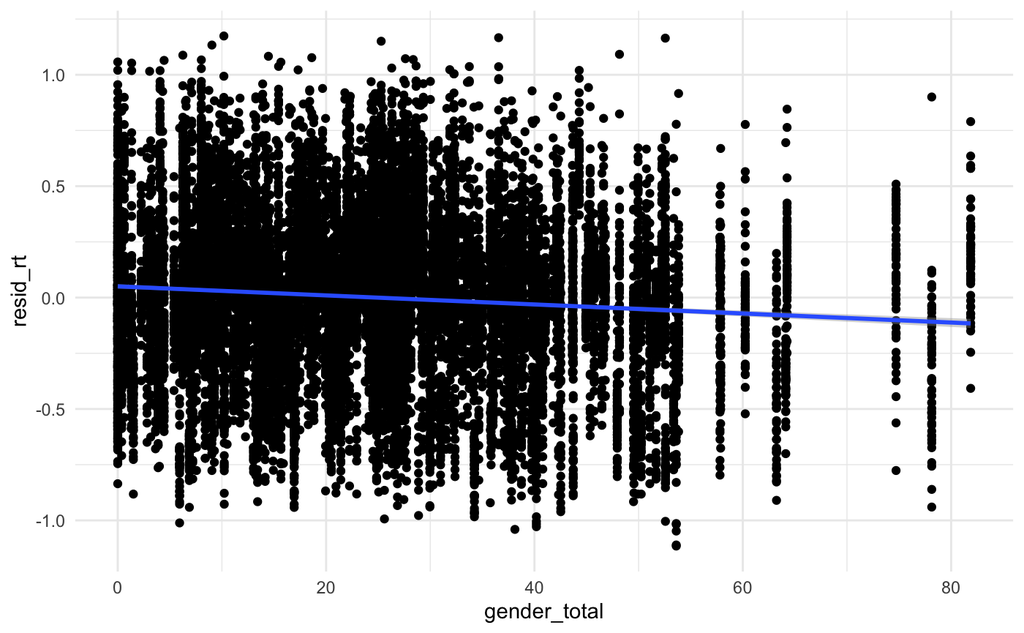

```r
ggplot(sprt_data_comp, aes(x=gender_total, y=resid_rt)) +
  geom_point() +
  geom_smooth(method="lm")
```

```r
sprt_data_comp <- sprt_data_comp %>%
  mutate(trial_gender = as.factor(trial_gender)) %>%
  mutate(c_gender_total = scale(gender_total,scale=FALSE)) %>%
  mutate(c_trial_gender = scale(as.numeric(trial_gender),scale=FALSE))
```

```r
model_three <- lmer(resid_rt~c_gender_total*c_trial_gender + (1 + c_gender_total |name) + (1 + c_trial_gender|workerid) + (1 + c_trial_gender|lexeme), data=sprt_data_comp)
```

```r
summary(model_three)
```

```
Linear mixed model fit by REML. t-tests use Satterthwaite's method ['lmerModLmerTest']
Formula: resid_rt ~ c_gender_total * c_trial_gender + (1 + c_gender_total |      name) + (1 + c_trial_gender | workerid) + (1 + c_trial_gender |      lexeme)
   Data: sprt_data_comp

REML criterion at convergence: 3642.9

Scaled residuals:
    Min      1Q  Median      3Q     Max
-4.7983 -0.6031 -0.0423  0.5581  5.2443

Random effects:
 Groups   Name           Variance  Std.Dev. Corr
 workerid (Intercept)    6.043e-02 0.245825
          c_trial_gender 8.681e-04 0.029464 0.05
 name     (Intercept)    2.242e-04 0.014972
          c_gender_total 2.238e-05 0.004731 0.44
 lexeme   (Intercept)    9.798e-05 0.009899
          c_trial_gender 3.780e-05 0.006148 -0.52
 Residual                6.760e-02 0.260008
Number of obs: 16045, groups:  workerid, 279; name, 24; lexeme, 20

Fixed effects:
                                Estimate Std. Error         df t value Pr(>|t|)
(Intercept)                     0.006333   0.015333 291.865668   0.413    0.680
c_gender_total                 -0.034616   0.014908 276.799393  -2.322    0.021 *
c_trial_gender                 -0.001135   0.004311  32.465678  -0.263    0.794
c_gender_total:c_trial_gender  -0.000971   0.002880  48.032572  -0.337    0.737
---
Signif. codes:  0 ‘***’ 0.001 ‘**’ 0.01 ‘*’ 0.05 ‘.’ 0.1 ‘ ’ 1

Correlation of Fixed Effects:
            (Intr) c_gnd_ c_trl_
c_gendr_ttl  0.005
c_tril_gndr -0.004  0.000
c_gndr_t:__  0.000  0.031  0.104
```

[^1]: It is my hope and intention that this color palette be color-blind friendly. If you have accessibility concerns, please do not hesitate to reach out to me!
[^2]: This amounts to an hourly rate of $20.73. We originally anticipated that participants would take an average of 7 minutes to complete the experiment, and set the base pay at $15 an hour.